# Caso Práctico 7

Marcos Barragán

13/12/2020

Cargamos los datos necesarios para este caso, que serán las series de precios de los activos de BMW y Volkswagen. Realmente los que nos interesan son los precios de cierre ajustados, así que será con los que me quedaré posteriormente.

```r
getSymbols('BMW.DE', from = '2014-01-01', to = Sys.Date())
```

[output not shown]

```
## [1] "BMW.DE"
```

```r
# Despreciamos los NA's:

BMW <- na.omit(BMW.DE)

BMW_adj <- BMW$BMW.DE.Adjusted

colnames(BMW_adj) <- c("Close")
```

```r
getSymbols('VOW.DE', from = '2014-01-01', to = Sys.Date())
```

```
## [1] "VOW.DE"
```

```r
# Despreciamos los NA's:

VW <- na.omit(VOW.DE)

VW_adj <- VW$VOW.DE.Adjusted

colnames(VW_adj) <- c("Close")
```

Unimos ambos para tener los mismos precios de cierre ajustados en un único objeto:

```r
BMW_VW <- cbind(BMW_adj, VW_adj)

names(BMW_VW) <- c('BMW', 'VW')
```

Para tener un apoyo visual sobre lo que vamos a estudiar más adelante, llevaré a cabo una representación de la serie temporal de `BMW` y `Volkswagen`.

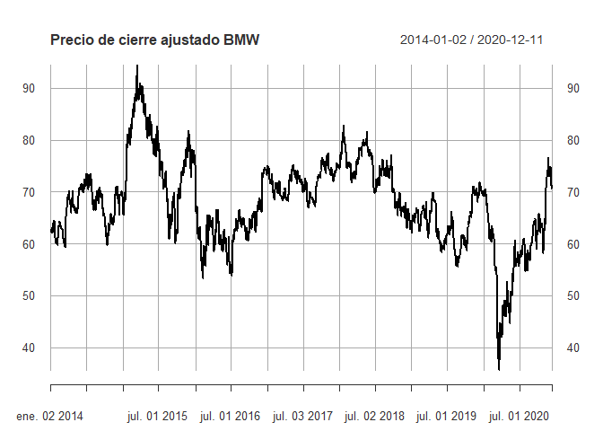

```r
plot(BMW_adj, main = "Precio de cierre ajustado BMW")
```

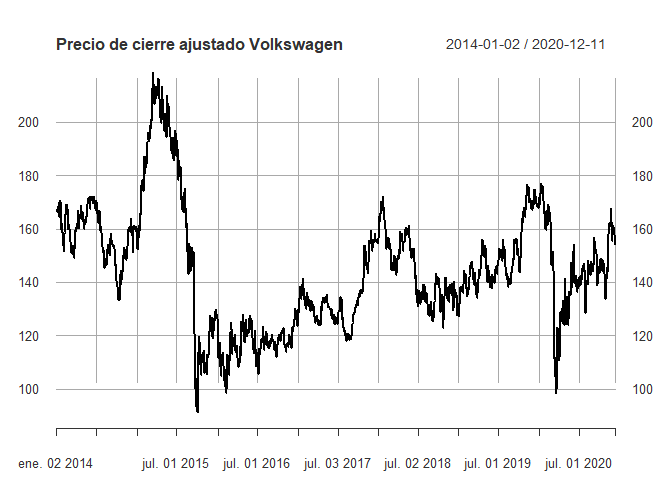

```r
plot(VW_adj, main = "Precio de cierre ajustado Volkswagen")
```

Si las escalamos, para verlas en conjunto:

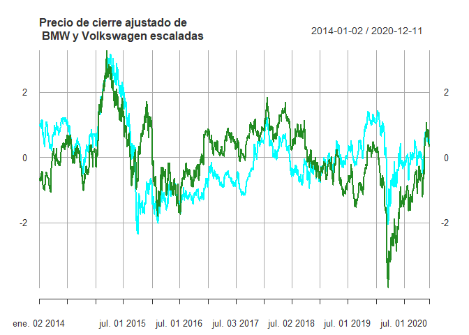

```r
plot(scale(BMW_VW), main = 'Precio de cierre ajustado de \n BMW y Volkswagen escaladas', col = c('Forestgreen', 'cyan'))
```

De acuerdo con la información obtenida en la fuente [ABC](https://www.abc.es/economia/abci-dieselgate-escandalo-sin-fecha-caducidad-cumple-primer-aniversario-201609190212_noticia.html?ref=https:%2F%2Fwww.google.com%2F), consideraré el inicio del caso *“Diesel Gate”* el día 1 de Septiembre de 2015.

Dividiendo los tiempos entre pre y post escándalo, tendremos:

```r
pre <- as.Date(c("2014-01-01", "2015-09-01"))

post <- as.Date(c("2015-09-02", "2020-12-11"))
```

A continuación implementaré los modelo de *causal impact* (dentro de la librería con su mismo nombre) para los dos activos por separado.

### Impacto de BMW frente a Volkswagen

En primer lugar, consideraré el caso en el que intentamos explicar qué ocurrió con los precios de `BMW` cuando salió a la luz el escándalo citado sobre `Volkswagen`.

```r
modelo_causal <- CausalImpact(BMW_VW, pre.period = pre, post.period = post)
```

Una vez estimado el modelo, llevaré a cabo una representación y un resumen de los resultados obtenidos en el mismo. En dicho resumen será donde aparezcan los resultados y el efecto del escándalo en los precios de los activos.

```r
summary(modelo_causal)
```

```
## Posterior inference {CausalImpact}
##
##                          Average       Cumulative
## Actual                   67            89298
## Prediction (s.d.)        60 (6.6)      80129 (8817.6)
## 95% CI                   [48, 73]      [63713, 98271]
##
## Absolute effect (s.d.)   6.8 (6.6)     9169.1 (8817.6)
## 95% CI                   [-6.7, 19]    [-8972.6, 25585]
##
## Relative effect (s.d.)   11% (11%)     11% (11%)
## 95% CI                   [-11%, 32%]   [-11%, 32%]
##
## Posterior tail-area probability p:   0.15085
## Posterior prob. of a causal effect:  85%
##
## For more details, type: summary(impact, "report")
```

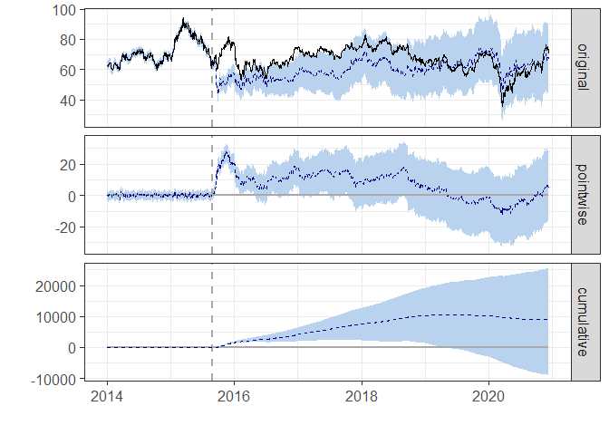

```r
plot(modelo_causal)
```

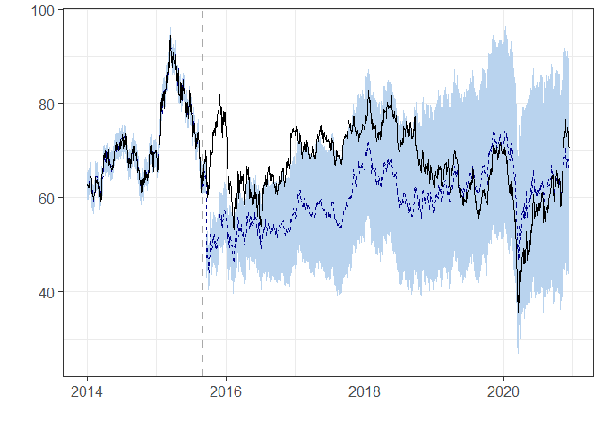

```r
plot(modelo_causal, "original")
```

El paquete *CausalImpact* presenta una ventaja bastante grande, y es que elabora automáticamente un reporte de lo que ha ocurrido al estimar el modelo causal. Para ello, simplemente debemos indicarle al hacer el *summary* la opción de *report*.

```r
summary(modelo_causal, 'report')
```

[output not shown]

### Impacto del caso en Volkswagen

En segundo lugar, estimaremos el efecto que pudo tener el caso de corrupción en el precio de Volkswagen.

Elaboramos, de la misma forma que en el caso anterior, el modelo de *Casual Impact* sobre este segundo vector, indicándole los mismos cortes de períodos de pre y post fecha del escándalo:

```r
modelo_causal_VW <- CausalImpact(VW_BMW, pre.period = pre, post.period = post)
```

En este caso, los resultados y los gráficos que obtenemos son de la forma:

```r
summary(modelo_causal_VW)
```

```
## Posterior inference {CausalImpact}
##
##                          Average      Cumulative
## Actual                   136          182749
## Prediction (s.d.)        155 (16)     207564 (21675)
## 95% CI                   [124, 189]   [166161, 252413]
##
## Absolute effect (s.d.)   -19 (16)     -24815 (21675)
## 95% CI                   [-52, 12]    [-69664, 16588]
##
## Relative effect (s.d.)   -12% (10%)   -12% (10%)
## 95% CI                   [-34%, 8%]   [-34%, 8%]
##
## Posterior tail-area probability p:   0.1247
## Posterior prob. of a causal effect:  88%
##
## For more details, type: summary(impact, "report")
```

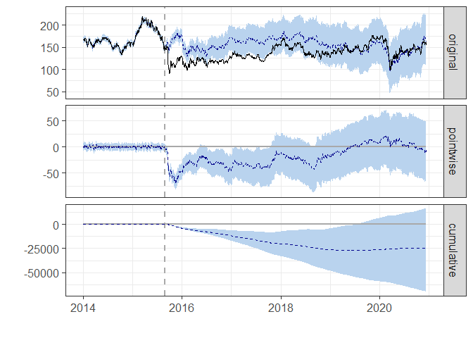

```r
plot(modelo_causal_VW)
```

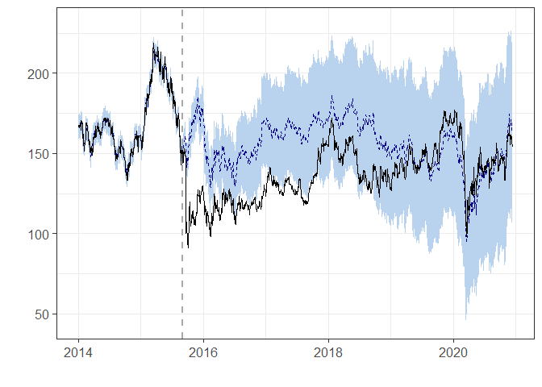

```r
plot(modelo_causal_VW, "original")
```

De nuevo, ejecutaré el reporte que tiene intrínseco el paquete de *CausalImpact* para verificar las conclusiones obtenidas.

```r
summary(modelo_causal_VW, 'report')
```

[output not shown]